# CEE218X Assignment #1

With a decrease in commercial energy consumption, we would expect to see a corresponding increase in residential energy consumption due to the coronavirus. This is somewhat visible in the signature of residential electricity usage. January and February were relatively low compared to the three previous years, then consumption rose to unusually high levels for March onwards. However, the spring appears to be a seasonal low point for residential electricity, so it will be interesting to see if consumption stays higher than normal through the summer as well. Interestingly there seems to be no effect of coronavirus on residential gas consumption.

```r
## create maps of consumption
kbtu.map <- kbtu %>%
  group_by(ZIP = ZCTA5CE10, CUSTOMERCLASS, MONTH, YEAR) %>%
  summarize(total_elec = Sum(TOTALKBTU_ELEC),
            avg_elec = total_elec / Sum(TOTALCUSTOMERS_ELEC),
            total_gas = Sum(TOTALKBTU_GAS),
            avg_gas = total_gas / Sum(TOTALCUSTOMERS_GAS)) %>%
  subset(!is.na(MONTH)) %>%
  mutate(date = ymd(paste(YEAR, MONTH, '1', sep = '-'))) %>%
  subset(MONTH == 4) %>%
  ungroup %>%
  select(ZIP, YEAR, CUSTOMERCLASS, total_elec) %>%
  st_drop_geometry %>%
  pivot_wider(names_from = YEAR, values_from = total_elec) %>%
  full_join(bay_zips %>% select(ZIP = ZCTA5CE10), ., by = 'ZIP') %>%
  setNames(make.names(names(.))) %>%
  mutate(absolute_diff = X2020 - X2019,
         percent_diff = ifelse(
           X2019 == 0 & X2020 == 0, 0,
           ifelse(X2019 == 0 & X2020 > 0, 1, (X2020 - X2019)/X2019)))

kbtu.map.res <- kbtu.map %>%
  subset(CUSTOMERCLASS == 'Residential')
kbtu.map.comm <- kbtu.map %>%
  subset(CUSTOMERCLASS == 'Commercial')
```

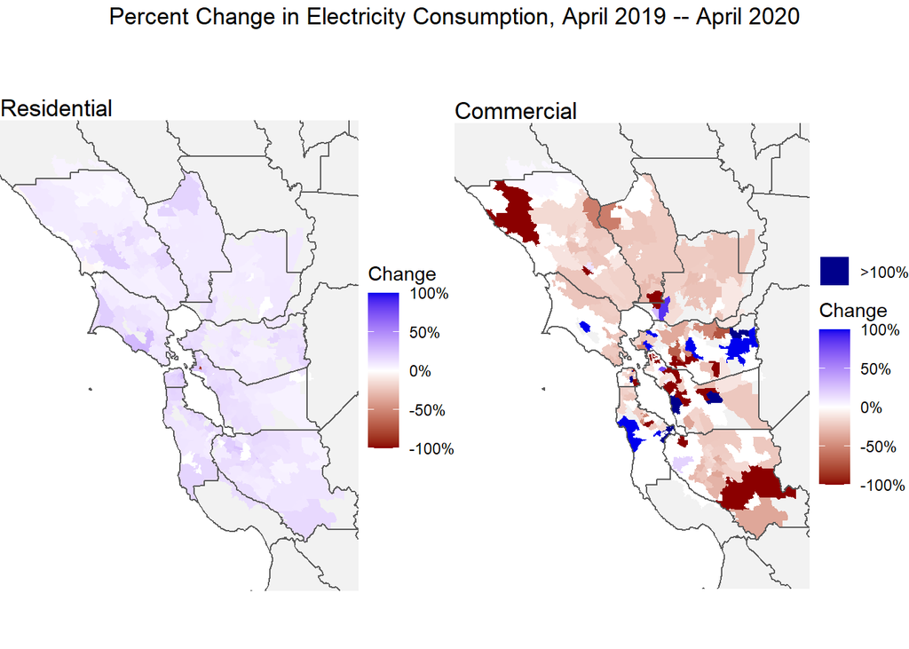

```r
## plot percent change in consumption from April 2019 to April 2020
g.res <- ggplot() +
  geom_sf(data = california, fill = 'grey95') +
  geom_sf(data = kbtu.map.res, aes(fill = percent_diff), color = NA) +
  scale_fill_gradient2(name = 'Change', labels = percent,
                       low = 'darkred', high = 'blue2',
                       limits = c(-1, 1), na.value = NA) +
  geom_sf(data = california, fill = NA) +
  ggtitle('Residential') +
  lims(x = c(-123.5, -121.33), y = c(36.75, 39)) +
  theme_void()
g.comm <- ggplot() +
  geom_sf(data = california, fill = 'grey95') +
  geom_sf(data = kbtu.map.comm,
          aes(fill = percent_diff), color = NA) +
  scale_fill_gradient2(name = 'Change', labels = percent,
                       low = 'darkred', high = 'blue2',
                       limits = c(-1, 1), na.value = NA) +
  ggnewscale::new_scale_fill() +
  geom_sf(data = kbtu.map.comm %>% subset(percent_diff > 1), aes(fill = '>100%'), color = NA) +
  scale_fill_manual(name = '', values = 'blue4') +
  geom_sf(data = california, fill = NA) +
  ggtitle('Commercial') +
  lims(x = c(-123.5, -121.33), y = c(36.75, 39)) +
  theme_void()
grid.arrange(g.res, g.comm, ncol = 2,
             top = textGrob('Percent Change in Electricity Consumption, April 2019 -- April 2020',
                            vjust = 0.5, gp = gpar(cex = 1.1)))
```

The map of commercial electricity consumption, on the other hand, has a lot more variation. 43.46% of zip codes had no commercial electricity consumption reported in either year, so these are shown as white. Zip codes with zero consumption in April 2019 and nonzero consumption in April 2020 were said to have 100% percent change. Conversely, zip codes with nonzero consumption in April 2019 and zero consumption in April 2020 were said to have -100% percent change. A handful of zip codes even had a percent change greater than 100%, which are displayed separately from the gradient scale. Apart from these outliers, the general trend seems to be a moderate regional decrease in commercial electricity consumption. The average percent change is -10.47%, or about 3,851,726 fewer KBTUs per zip code. The places with large swings in commercial energy consumption are scattered throughout the Bay Area without a clear pattern. One possible explanation may be that these locations represent concentrations of specific industries that responded to the coronavirus in different ways, but more exploration would be necessary to confirm or refute that hypothesis.

```r
## make the percent change maps interactive
domain <- c(-100, 100)
colorPal <- c(colorRampPalette(colors = c("#b2182b", "white"), space = "Lab")(100),
              colorRampPalette(colors = c("white", "#2166ac"), space = "Lab")(100))

leaflet() %>%
  addTiles() %>%
  addPolygons(data = kbtu.map.res %>%
                subset(percent_diff != 0) %>%
                mutate(percent_diff = 100*percent_diff) %>%
                st_transform(crs_leaflet),
              color = 'gray', weight = 1,
              fillColor = ~get('colorBin')(colorPal, domain)(percent_diff),
              fillOpacity = 0.9,
              label = ~paste0(ZIP, ": ", round(percent_diff,2), '%')) %>%
  addPolygons(data = kbtu.map.res %>%
                subset(percent_diff == 0) %>%
                mutate(percent_diff = 100*percent_diff) %>%
                st_transform(crs_leaflet),
              color = 'gray', weight = 1,
              fillColor = 'white',
              fillOpacity = 0.9,
              label = ~paste0(ZIP, ": ", round(percent_diff,2), '%')) %>%
  addLegend("topright",
            pal = colorBin(colorPal, domain = domain),
            values = domain, opacity = 0.9)
```

[interactive chart not shown]

```r
leaflet() %>%
  addTiles() %>%
  addPolygons(data = kbtu.map.comm %>%
                subset(percent_diff != 0) %>%
                mutate(percent_diff = 100*percent_diff) %>%
                st_transform(crs_leaflet),
              color = 'gray', weight = 1,
              fillColor = ~get('colorBin')(colorPal, domain)(percent_diff),
              fillOpacity = 0.9,
              label = ~paste0(ZIP, ": ", round(percent_diff,2), '%')) %>%
  addPolygons(data = kbtu.map.comm %>%
                subset(percent_diff == 0) %>%
                mutate(percent_diff = 100*percent_diff) %>%
                st_transform(crs_leaflet),
              color = 'gray', weight = 1,
              fillColor = 'white',
              fillOpacity = 0.9,
              label = ~paste0(ZIP, ": ", round(percent_diff,2), '%')) %>%
  addLegend("topright",
            pal = colorBin(colorPal, domain = domain),
            values = domain, opacity = 0.9)
```

[interactive chart not shown]